# Prepare stomach content data

Author

Max Lindmark

Published

September 23, 2023

## Load libraries

```r
library(tidyverse)
library(tidylog)
library(janitor)
library(devtools)
library(sdmTMB)
library(mapplots)

# Import some plotting functions
# Source code for map plots
# You need: # devtools::install_github("seananderson/ggsidekick") # not on CRAN; library(ggsidekick)
devtools::source_url("https://raw.githubusercontent.com/maxlindmark/pred-prey-overlap/main/R/functions/map-plot.R")
options(ggplot2.continuous.colour = "viridis")

# Set path
home <- here::here()
```

## Read data

Sent from Nis as a backup to the ICES data base updated in SCINEA SC10

```r
pred <- read_delim(paste0(home, "/data/stomach/predator_table.txt"))
prey <- read_delim(paste0(home, "/data/stomach/prey_table.txt"))
```

```r
pred <- read_delim(paste0(home, "/data/stomach/predator_table.txt"))
prey <- read_delim(paste0(home, "/data/stomach/prey_table.txt"))
# Join the predator information to the prey data
intersect(colnames(pred), colnames(prey))
```

```
[1] "stomID"
```

```r
d <- prey |>
  left_join(pred) |>
  filter(Year > 1992) |>
  as.data.frame() |>
  mutate_at(c("Prey_size", "Prey_weight", "Prey_nr", "latPosStartDec", "lonPosStartDec", "Pred_size", "Pred_weight"),
            as.numeric)
```

```
left_join: added 20 columns (Year, month, Day, Quarter, SD, …)
> rows only in x 0
> rows only in y ( 0)
> matched rows 198,301
> =========
> rows total 198,301
filter: removed 157,449 rows (79%), 40,852 rows remaining
```

```
mutate_at: converted 'Prey_size' from character to double (23717 new NA)
           converted 'Prey_weight' from character to double (3856 new NA)
           converted 'Prey_nr' from character to double (10902 new NA)
           converted 'latPosStartDec' from character to double (21307 new NA)
           converted 'lonPosStartDec' from character to double (22066 new NA)
           converted 'Pred_weight' from character to double (13071 new NA)
```

```r
str(d)
```

```
'data.frame':   40852 obs. of  27 variables:
 $ stomID                : chr  "2007_11_3_3_DAN2_39G5_20_M_280_214_1" "2007_11_3_3_DAN2_39G5_25_F_250_146_1" "2007_11_3_3_DAN2_39G5_25_F_250_146_1" "2007_11_3_3_DAN2_39G5_8_M_300_240_1" ...
 $ prey_sp               : chr  "Annelida" "Cumacea" "Saduria entomon" "Saduria entomon" ...
 $ Length_code           : chr  "NULL" "NULL" "NULL" "NULL" ...
 $ Prey_size             : num  NA NA NA NA NA NA NA NA NA NA ...
 $ Prey_weight           : num  1.02 0.59 0.11 0.42 NA 1.34 0.1 0.1 0.98 0.28 ...
 $ Prey_nr               : num  3 52 1 30 NA 130 3 1 90 8 ...
 $ Stage_digestion       : chr  "1" "1" "1" "1" ...
 $ Year                  : num  2007 2007 2007 2007 2007 ...
 $ month                 : chr  "11" "11" "11" "11" ...
 $ Day                   : chr  "3" "3" "3" "3" ...
 $ Quarter               : num  4 4 4 4 4 4 4 4 4 4 ...
 $ SD                    : chr  "25" "25" "25" "25" ...
 $ square                : chr  "39G5" "39G5" "39G5" "39G5" ...
 $ latPosStartDec        : num  55.3 55.3 55.3 55.3 55.3 ...
 $ lonPosStartDec        : num  15.2 15.2 15.2 15.2 15.2 ...
 $ Coun_                 : chr  "DEN" "DEN" "DEN" "DEN" ...
 $ Ship                  : chr  "DAN2" "DAN2" "DAN2" "DAN2" ...
 $ cruise                : chr  "BITS-2" "BITS-2" "BITS-2" "BITS-2" ...
 $ station               : chr  "3" "3" "3" "3" ...
 $ Method                : chr  "DEM" "DEM" "DEM" "DEM" ...
 $ Predator_code         : chr  "COD" "COD" "COD" "COD" ...
 $ FERL                  : num  1 1 1 1 0 1 1 1 1 1 ...
 $ Pred_size             : num  280 250 250 300 460 370 370 370 420 510 ...
 $ Pred_weight           : num  214 146 146 240 1034 ...
 $ Predator_gutted_weight: chr  "NULL" "NULL" "NULL" "NULL" ...
 $ sexCode               : chr  "M" "F" "F" "M" ...
 $ maturityIndex         : chr  "NULL" "NULL" "NULL" "NULL" ...
```

Next we need to summarize our prey weights by predator and prey group. First filter stomachs where these prey are present. Create a new common name column to make life easier…

```r
names(d)
```

```
 [1] "stomID"                 "prey_sp"                "Length_code"
 [4] "Prey_size"              "Prey_weight"            "Prey_nr"
 [7] "Stage_digestion"        "Year"                   "month"
[10] "Day"                    "Quarter"                "SD"
[13] "square"                 "latPosStartDec"         "lonPosStartDec"
[16] "Coun_"                  "Ship"                   "cruise"
[19] "station"                "Method"                 "Predator_code"
[22] "FERL"                   "Pred_size"              "Pred_weight"
[25] "Predator_gutted_weight" "sexCode"                "maturityIndex"
```

```r
unique(d$prey_sp)
```

```
  [1] "Annelida"                    "Cumacea"
  [3] "Saduria entomon"             "Empty"
  [5] "Mysis mixta"                 "Pisces"
  [7] "Bylgides sp."                "Gammarus sp."
  [9] "Macoma balthica"             "Mysidae"
 [11] "Hyperia galba"               "Lost"
 [13] "Halicryptus spinulosus"      "Pontoporeia femorata"
 [15] "Stone"                       "Clupea harengus"
 [17] "Gadus morhua"                "Enchelyopus cimbrius"
 [19] "Sprattus sprattus"           "Clupeidae"
 [21] "Gobiidae"                    "Priapulus caudatus"
 [23] "Mytilus edulis"              "Terebellides stroemii"
 [25] "Neomysis integer"            "Monoporeia affinis"
 [27] "Plastic"                     "Insecta"
 [29] "Scales"                      "Regurgitated"
```

[output cut: 36 more lines]

```r
selected_prey_present <- d |>
  filter(prey_sp %in% c("Sprattus sprattus", "Clupea harengus", "Saduria entomon"))
```

```
filter: removed 20,720 rows (51%), 20,132 rows remaining
```

Check how many predators have these prey in stomachs

```r
length(unique(selected_prey_present$stomID))
```

```
[1] 8336
```

```r
length(unique(d$stomID))
```

```
[1] 17397
```

```r
length(unique(selected_prey_present$stomID)) / length(unique(d$stomID))
```

```
[1] 0.4791631
```

# Replace NA weights with estimated weights based on length, and drop the rest

```r
# First find out which unit length is in
unique(selected_prey_present$Length_code)
```

```
[1] "NULL" "sl"   "tl"   "rsl"  "ml"   "ra"
```

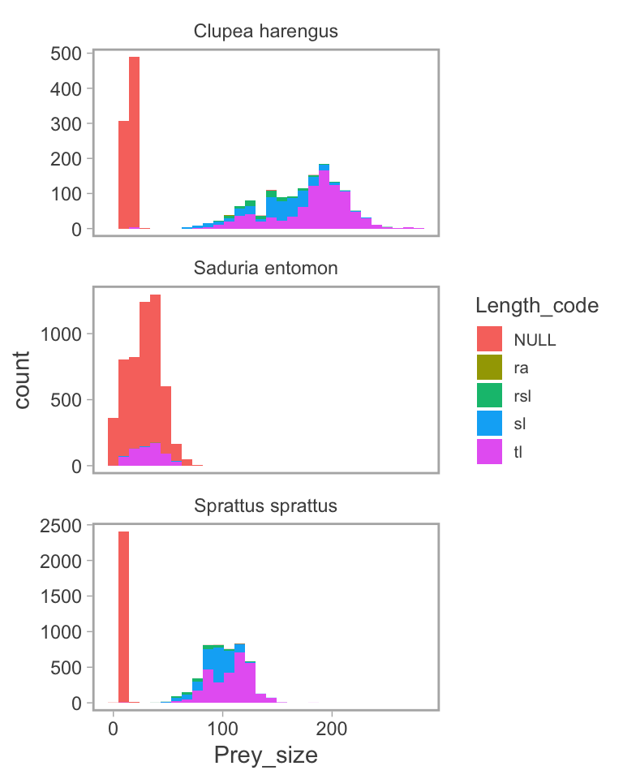

```r
ggplot(selected_prey_present, aes(Prey_size, fill = Length_code)) +
  geom_histogram() +
  facet_wrap(~prey_sp, scales = "free_y", ncol = 1)
```

```r
# Hmm, this is totally weird. Looks like cm if NULL in herring and sprat, but in Saduria it must be mm if NULL

selected_prey_present <- selected_prey_present |>
  mutate(Prey_size = ifelse(prey_sp == "Clupea harengus" & Length_code == "NULL", Prey_size*10, Prey_size),
         #Prey_size = ifelse(prey_sp == "Saduria entomon" & Length_code == "NULL", Prey_size*10, Prey_size),
         Prey_size = ifelse(prey_sp == "Sprattus sprattus" & Length_code == "NULL", Prey_size*10, Prey_size))
```

```
mutate: changed 3,230 values (16%) of 'Prey_size' (0 new NA)
```

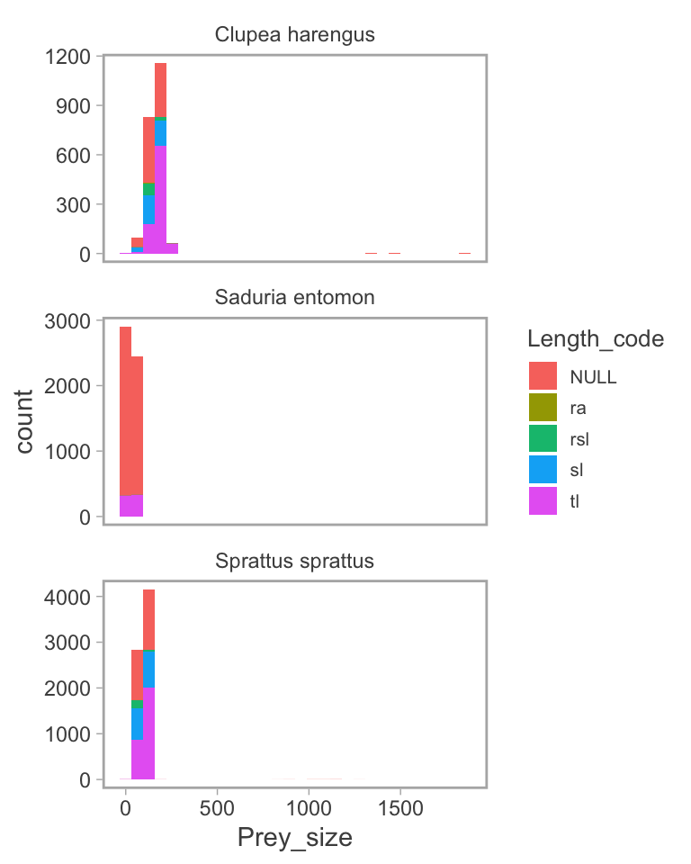

```r
ggplot(selected_prey_present, aes(Prey_size, fill = Length_code)) +
  geom_histogram() +
  facet_wrap(~prey_sp, scales = "free_y", ncol = 1)
```

```
filter: removed 5,635 rows (28%), 14,497 rows remaining
```

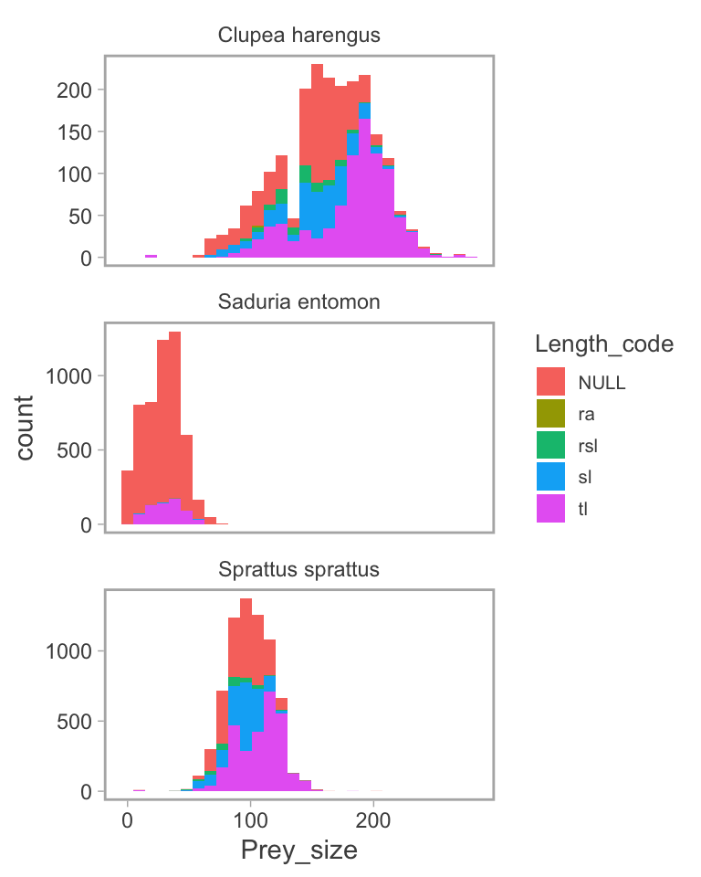

```r
ggplot(selected_prey_present |> filter(Prey_size < 750), aes(Prey_size, fill = Length_code)) +
  geom_histogram() +
  facet_wrap(~prey_sp, scales = "free_y", ncol = 1)
```

```r
# This is now in mm

unique(is.na(selected_prey_present$Prey_weight))
```

```
[1] FALSE  TRUE
```

```r
min(selected_prey_present$Prey_weight, na.rm = TRUE)
```

```
[1] 0.001
```

```r
# Do they have a length? Can we estimate Weight? If length is not `NA` and Weight is 0, estimate weight based on length and multiply with the count of prey. Else give weight `NA` and drop it.
selected_prey_present <- selected_prey_present |>
  mutate(weight_source = ifelse(is.na(Prey_weight) & !is.na(Prey_size), "estimated", "observed")) |>
  mutate(Prey_weight = ifelse(weight_source == "estimated", (0.01*(Prey_size/10)^3), Prey_weight))
```

```
mutate: new variable 'weight_source' (character) with 2 unique values and 0% NA
mutate: changed 118 values (1%) of 'Prey_weight' (118 fewer NA)
```

```r
selected_prey_present <- selected_prey_present |> drop_na(Prey_weight)
```

```
drop_na: removed 84 rows (<1%), 20,048 rows remaining
```

```
filter: removed 11,665 rows (58%), 8,383 rows remaining
```

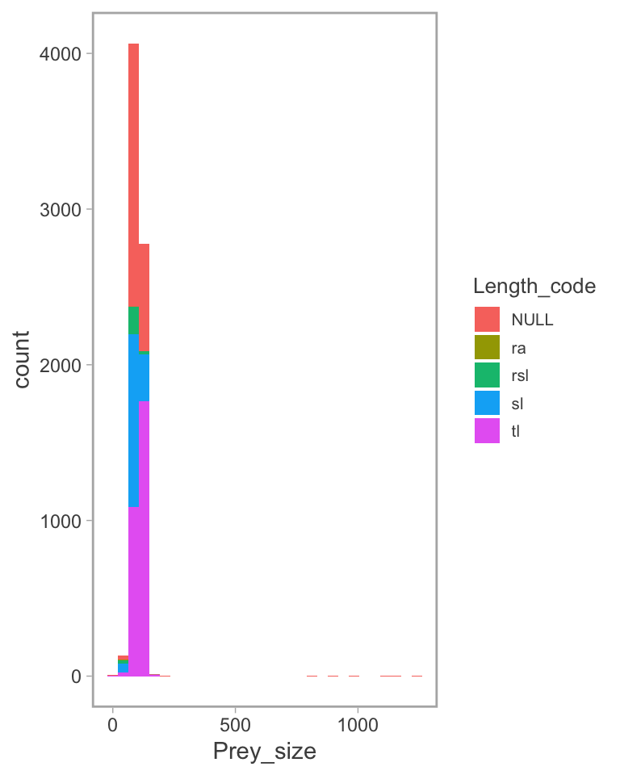

```r
selected_prey_present |>
  filter(prey_sp == "Sprattus sprattus") |>
  ggplot(aes(Prey_size, fill = Length_code)) +
  geom_histogram()
```

Now calculate the total weight of these prey per individual predator stomach, and then pivot wider.

```r
selected_prey_present_summed <- selected_prey_present |>
  group_by(stomID, prey_sp) |>
  summarise(tot_weight = sum(Prey_weight)) |>
  ungroup()
```

```
group_by: 2 grouping variables (stomID, prey_sp)
```

```
summarise: now 9,680 rows and 3 columns, one group variable remaining (stomID)
```

```
ungroup: no grouping variables
```

```r
selected_prey_present_summed <- selected_prey_present_summed |>
  pivot_wider(names_from = "prey_sp", values_from = "tot_weight", values_fill = 0)
```

```
pivot_wider: reorganized (prey_sp, tot_weight) into (Clupea harengus, Sprattus sprattus, Saduria entomon) [was 9680x3, now 8272x4]
```

Next I will `left_join` in the remaining predator information, and after that `bind_rows` “empty stomachs” (with respect to these 3 prey species). Since the IDs are not overlapping, it doesn’t matter that I already have some 0’s here for some species

```r
selected_prey_present_summed <- selected_prey_present_summed |>
  left_join(selected_prey_present, by = "stomID")
```

```
left_join: added 27 columns (prey_sp, Length_code, Prey_size, Prey_weight, Prey_nr, …)
```

```
           > rows only in x        0
```

```
           > rows only in y  (     0)
```

```
           > matched rows     20,048    (includes duplicates)
```

```
           >                 ========
```

```
           > rows total       20,048
```

```r
empty <- d |> filter(!stomID %in% c(selected_prey_present_summed$stomID))
```

```
filter: removed 27,506 rows (67%), 13,346 rows remaining
```

```r
dd <- bind_rows(selected_prey_present_summed, empty)

# Yes, works as intended, see the added NAs in the selected prey weights. Make them 0!
dd <- dd |>
  rename(herring = `Clupea harengus`,
         sprat = `Sprattus sprattus`,
         saduria = `Saduria entomon`) |>
  mutate(saduria = ifelse(is.na(saduria), 0, saduria),
         herring = ifelse(is.na(herring), 0, herring),
         sprat   = ifelse(is.na(sprat), 0, sprat))
```

```
rename: renamed 3 variables (herring, sprat, saduria)
```

```
mutate: changed 13,346 values (40%) of 'herring' (13346 fewer NA)
```

```
        changed 13,346 values (40%) of 'sprat' (13346 fewer NA)
```

```
        changed 13,346 values (40%) of 'saduria' (13346 fewer NA)
```

Trim the data a bit!

```r
dd <- dd |>
  mutate(lat = latPosStartDec,
         lon = lonPosStartDec,
         lat = ifelse(lat < 54, ices.rect(square)$lat, lat),
         lon = ifelse(lon < 54, ices.rect(square)$lon, lon),
         lat = ifelse(is.na(lat), ices.rect(square)$lat, lat),
         lon = ifelse(is.na(lon), ices.rect(square)$lon, lon)) |>
  drop_na(lon) |>
  drop_na(lat) |>
  janitor::clean_names() |>
  mutate(pred_weight_source = ifelse(is.na(pred_weight) & !is.na(pred_size), "estimated", "observed")) |>
  mutate(pred_weight = ifelse(pred_weight_source == "estimated", (0.01*(pred_size/10)^3), pred_weight)) #|>
```

```
mutate: new variable 'lat' (double) with 382 unique values and 0% NA
```

```
        new variable 'lon' (double) with 8 unique values and 0% NA
```

```
drop_na: no rows removed
drop_na: no rows removed
```

```
mutate: new variable 'pred_weight_source' (character) with 2 unique values and 0% NA
```

```
mutate: changed 11,570 values (35%) of 'pred_weight' (11570 fewer NA)
```

```r
  #dplyr::select(year, quarter, lat, lon, lat_pos_start_dec, lon_pos_start_dec, pred_weight, pred_size, length_code, pred_weight_source, saduria, herring, sprat)

sort(unique(dd$year))
```

```
 [1] 1993 1994 1995 1996 1997 1998 1999 2000 2001 2002 2003 2004 2005 2006 2007
[16] 2008 2009 2010 2011 2012 2013 2014
```

```r
glimpse(dd)
```

```
Rows: 33,394
Columns: 34
$ stom_id                <chr> "1993_3_25_7_BPE_40G9_11_NA_490_NA_1", "1993_3_…
$ herring                <dbl> 34, 34, 34, 34, 34, 34, 0, 0, 0, 0, 0, 0, 0, 0,…
$ sprat                  <dbl> 0.00, 0.00, 0.00, 0.00, 0.00, 0.00, 23.94, 23.9…
$ saduria                <dbl> 0, 0, 0, 0, 0, 0, 0, 0, 0, 0, 0, 0, 0, 0, 0, 0,…
$ prey_sp                <chr> "Clupea harengus", "Clupea harengus", "Clupea h…
$ length_code            <chr> "NULL", "NULL", "NULL", "NULL", "NULL", "NULL",…
$ prey_size              <dbl> NA, NA, NA, NA, 90, NA, 118, 116, 120, NA, 118,…
$ prey_weight            <dbl> 4.46, 4.16, 4.23, 13.75, 5.00, 2.40, 16.48, 7.4…
$ prey_nr                <dbl> 1, 1, 1, 1, 1, 1, 1, 1, 1, 1, 1, 1, 1, 1, 2, 1,…
$ stage_digestion        <chr> "2", "2", "2", "2", "2", "2", "1", "2", "1", "2…
$ year                   <dbl> 1993, 1993, 1993, 1993, 1993, 1993, 1993, 1993,…
$ month                  <chr> "3", "3", "3", "3", "3", "3", "3", "3", "3", "3…
$ day                    <chr> "25", "25", "25", "25", "25", "25", "25", "25",…
```

[output cut: 21 more lines]

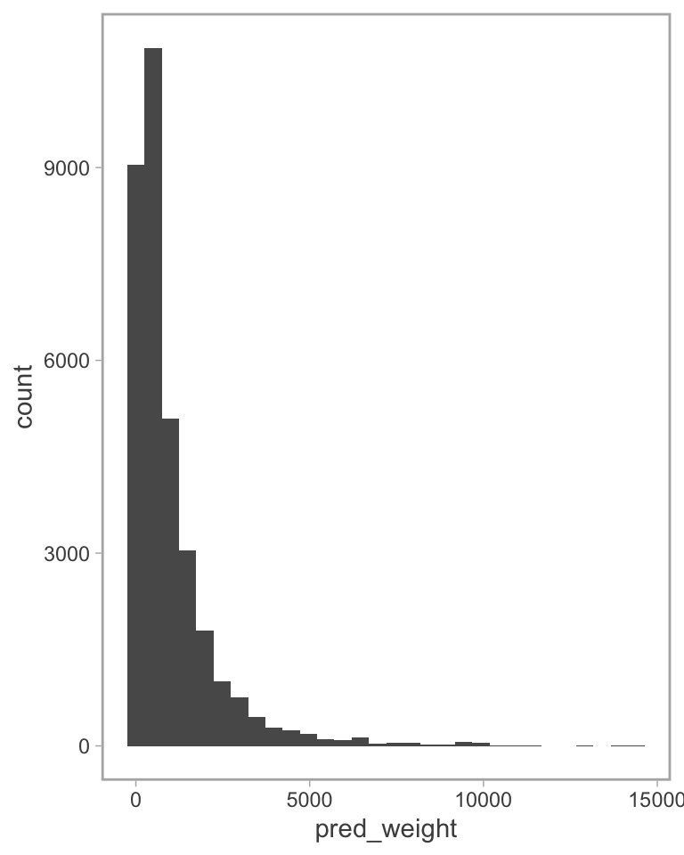

```r
# Ok, now summarise and plot these data. First calculate the feeding ratio, which is the weight of prey over predator weight
ggplot(dd, aes(pred_weight)) +
  geom_histogram()
```

```r
# Good, no NAs and all positive weight values. Calculate feeding ratios
dd <- dd |>
  mutate(FR_sad = saduria / pred_weight,
         FR_spr = sprat / pred_weight,
         FR_her = herring / pred_weight)
```

```
mutate: new variable 'FR_sad' (double) with 3,648 unique values and <1% NA
```

```
        new variable 'FR_spr' (double) with 3,657 unique values and <1% NA
```

```
        new variable 'FR_her' (double) with 2,015 unique values and <1% NA
```

Quick quality check

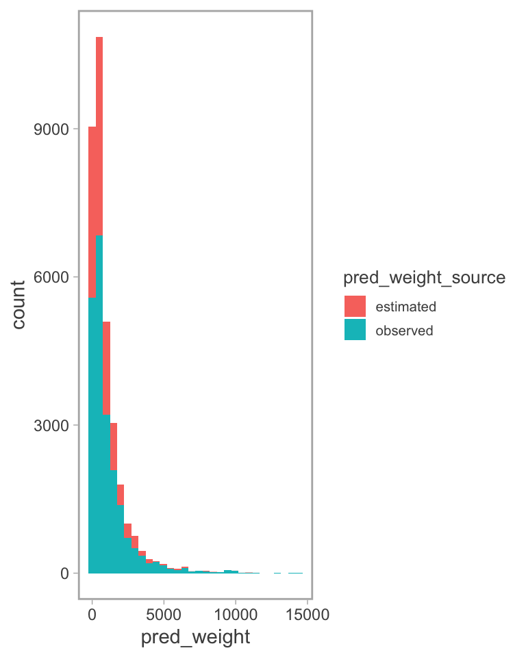

```r
ggplot(dd, aes(pred_weight, fill = pred_weight_source)) +
  geom_histogram()
```

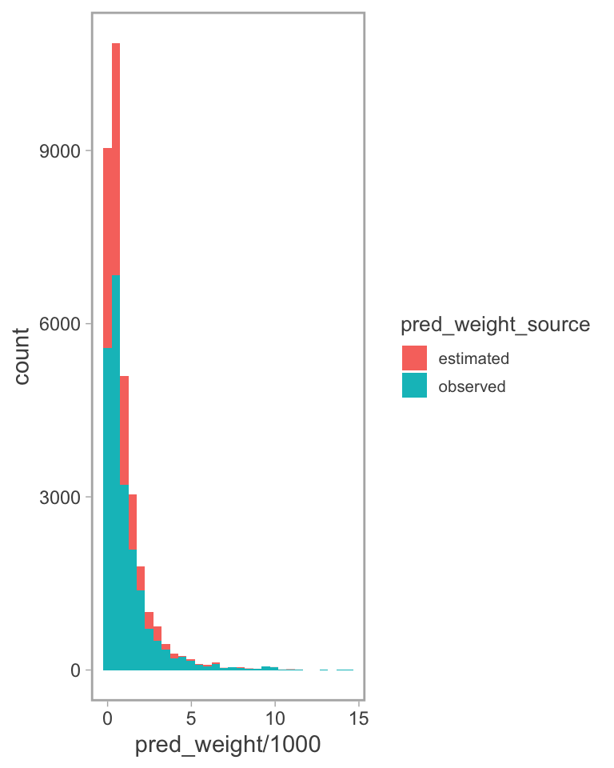

```r
ggplot(dd, aes(pred_weight/1000, fill = pred_weight_source)) +
  geom_histogram()
```

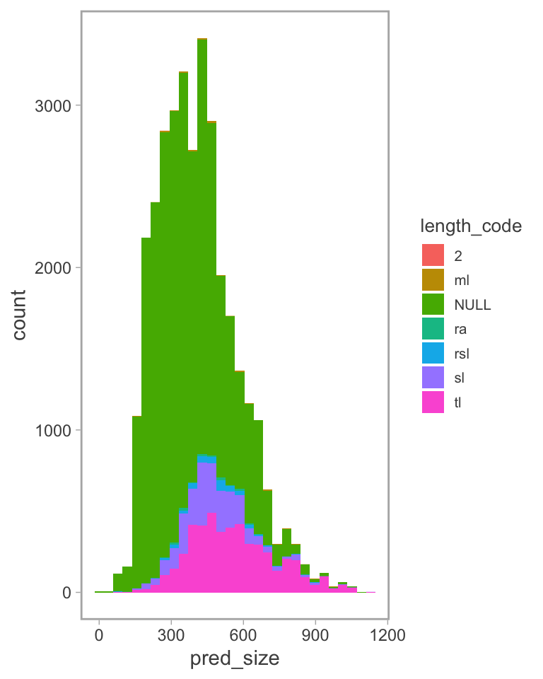

```r
ggplot(dd, aes(pred_size, fill = length_code)) +
  geom_histogram()
```

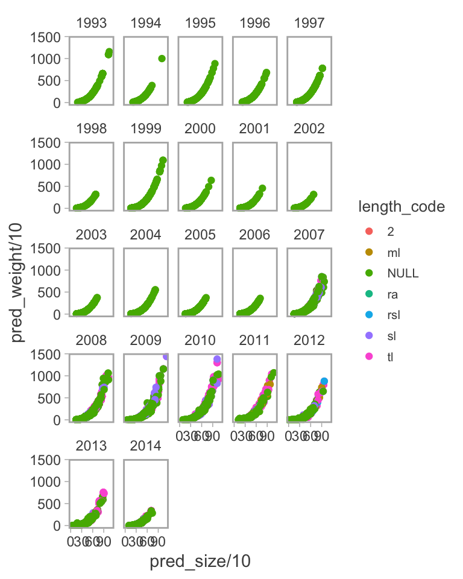

```r
ggplot(dd, aes(pred_size/10, pred_weight/10, color = length_code)) +
  geom_point() +
  facet_wrap(~year)
```

```
filter: removed 206 rows (1%), 33,188 rows remaining
```

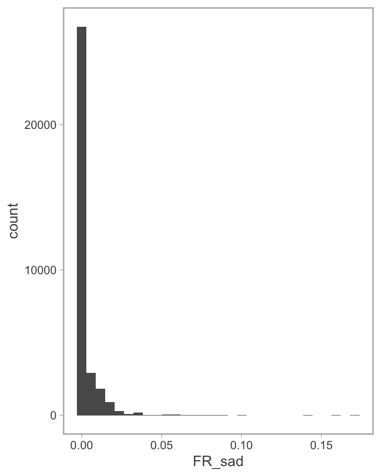

```r
dd |>
  filter(FR_sad < 0.3) |>
  ggplot(aes(FR_sad)) +
  geom_histogram() +
  #facet_wrap(~year) +
  NULL
```

```
filter: removed 351 rows (1%), 33,043 rows remaining
```

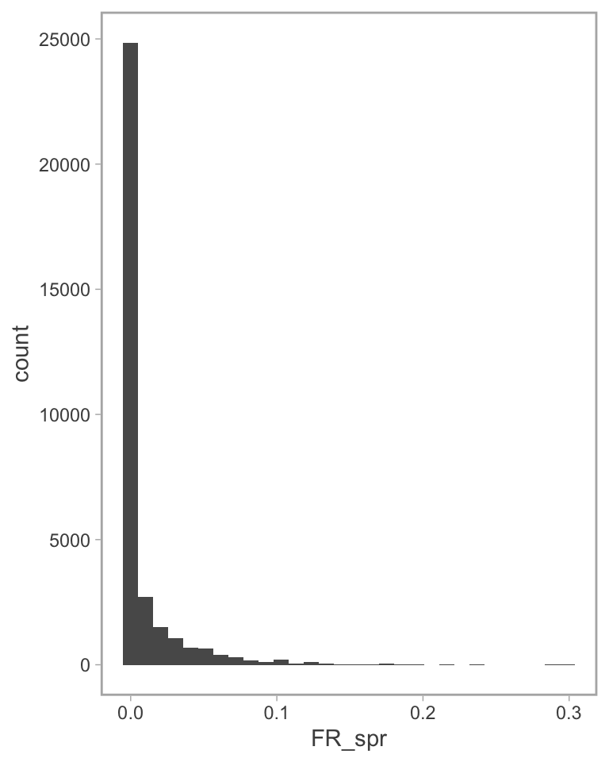

```r
dd |>
  filter(FR_spr < 0.3) |>
  ggplot(aes(FR_spr)) +
  geom_histogram() +
  #facet_wrap(~year) +
  NULL
```

```
filter: removed 193 rows (1%), 33,201 rows remaining
```

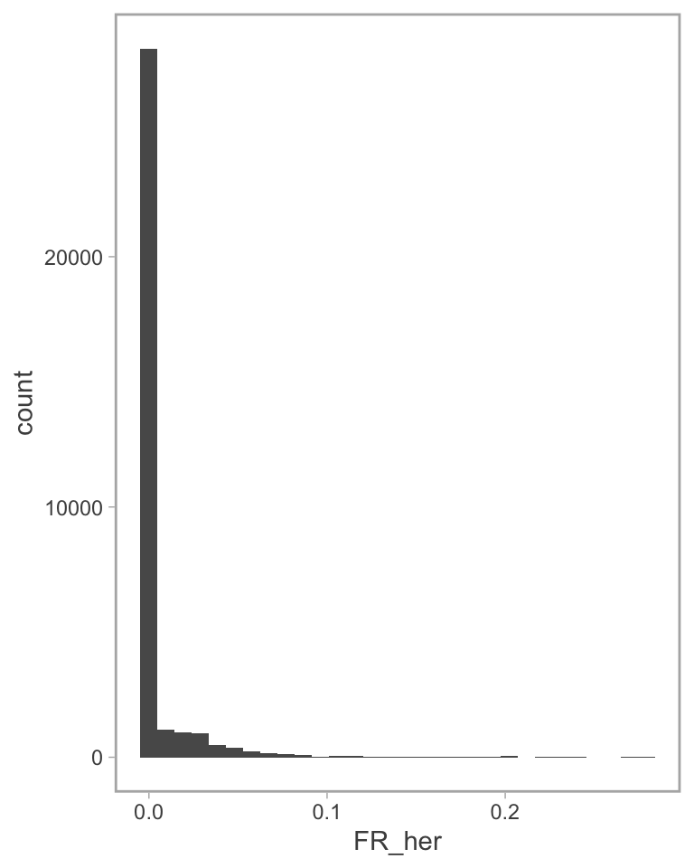

```r
dd |>
  filter(FR_her < 0.3) |>
  ggplot(aes(FR_her)) +
  geom_histogram() +
  #facet_wrap(~year) +
  NULL
```

```r
# Don't bother with these outliers, just filter
tt <- dd |>
  filter(FR_sad > 0.3) |> # FR_spr > 0.3 FR_her > 0.3) |>
  as.data.frame()
```

```
filter: removed 33,192 rows (99%), 202 rows remaining
```

```r
tt
```

```
                                      stom_id   herring    sprat   saduria
1        2007_11_8_126_DAN2_39G4_1_M_160_40_1     4.480    22.33    33.130
2        2007_11_8_126_DAN2_39G4_1_M_160_40_1     4.480    22.33    33.130
3        2007_11_8_126_DAN2_39G4_1_M_160_40_1     4.480    22.33    33.130
4        2007_11_8_126_DAN2_39G4_1_M_160_40_1     4.480    22.33    33.130
5        2007_11_8_126_DAN2_39G4_1_M_160_40_1     4.480    22.33    33.130
6        2007_11_8_126_DAN2_39G4_1_M_160_40_1     4.480    22.33    33.130
7        2007_11_8_126_DAN2_39G4_1_M_160_40_1     4.480    22.33    33.130
8        2007_11_8_126_DAN2_39G4_1_M_160_40_1     4.480    22.33    33.130
9        2007_11_8_126_DAN2_39G4_1_M_160_40_1     4.480    22.33    33.130
10       2007_11_8_126_DAN2_39G4_1_M_160_40_1     4.480    22.33    33.130
11       2007_11_8_126_DAN2_39G4_1_M_160_40_1     4.480    22.33    33.130
12       2007_11_8_126_DAN2_39G4_1_M_160_40_1     4.480    22.33    33.130
13       2007_11_8_126_DAN2_39G4_1_M_160_40_1     4.480    22.33    33.130
14       2007_11_8_126_DAN2_39G4_1_M_160_40_1     4.480    22.33    33.130
```

[output cut: 1203 more lines]

```r
prey |> filter(stomID == "2012_11_5_81_DANA2_41G7_1_F_400_554_1") # ????????
```

```
filter: removed 198,293 rows (>99%), 8 rows remaining
```

```
# A tibble: 8 × 7
  stomID       prey_sp Length_code Prey_size Prey_weight Prey_nr Stage_digestion
  <chr>        <chr>   <chr>       <chr>     <chr>       <chr>   <chr>
1 2012_11_5_8… Clupea… tl          165       33698       1       3
2 2012_11_5_8… Saduri… tl          35        0.686       1       1
3 2012_11_5_8… Saduri… tl          34        0.611       1       1
4 2012_11_5_8… Saduri… tl          41        1419        1       1
5 2012_11_5_8… Bylgid… NULL        NULL      3149        NULL    3
6 2012_11_5_8… Stickl… ml          NULL      6824        NULL    3
7 2012_11_5_8… Spine   ml          NULL      0.193       1       3
8 2012_11_5_8… Spine   ml          NULL      0.365       1       3
```

```r
dd <- dd |> filter(FR_sad < 0.3 & FR_spr < 0.3 & FR_her < 0.3)
```

```
filter: removed 610 rows (2%), 32,784 rows remaining
```

```r
dd %>%
  pivot_longer(c("herring", "saduria", "sprat")) |>
  group_by(name) |>
  summarise(prop_empty = sum(value == 0)/n(),
            prop_not_empty = sum(value != 0)/n())
```

```
pivot_longer: reorganized (herring, sprat, saduria) into (name, value) [was 32784x37, now 98352x36]
```

```
group_by: one grouping variable (name)
```

```
summarise: now 3 rows and 3 columns, ungrouped
```

```
# A tibble: 3 × 3
  name    prop_empty prop_not_empty
  <chr>        <dbl>          <dbl>
1 herring      0.826          0.174
2 saduria      0.685          0.315
3 sprat        0.689          0.311
```

Add UTM coords

```r
# Inspect spatiotemporal resolution of feeding ratio
dd <- dd |> add_utm_columns(ll_names = c("lon", "lat"), utm_crs = 32633)
```

```r
# Add sample size per coordinate for plotting
dd_plot <- dd |>
  group_by(year, X, Y) |>
  mutate(sample_size = n(),
         pos_id = paste(year, X, Y)) |>
  ungroup() |>
  distinct(pos_id, .keep_all = TRUE)
```

```
group_by: 3 grouping variables (year, X, Y)
```

```
mutate (grouped): new variable 'sample_size' (integer) with 175 unique values and 0% NA
```

```
                  new variable 'pos_id' (character) with 546 unique values and 0% NA
```

```
ungroup: no grouping variables
```

```
distinct: removed 32,238 rows (98%), 546 rows remaining
```

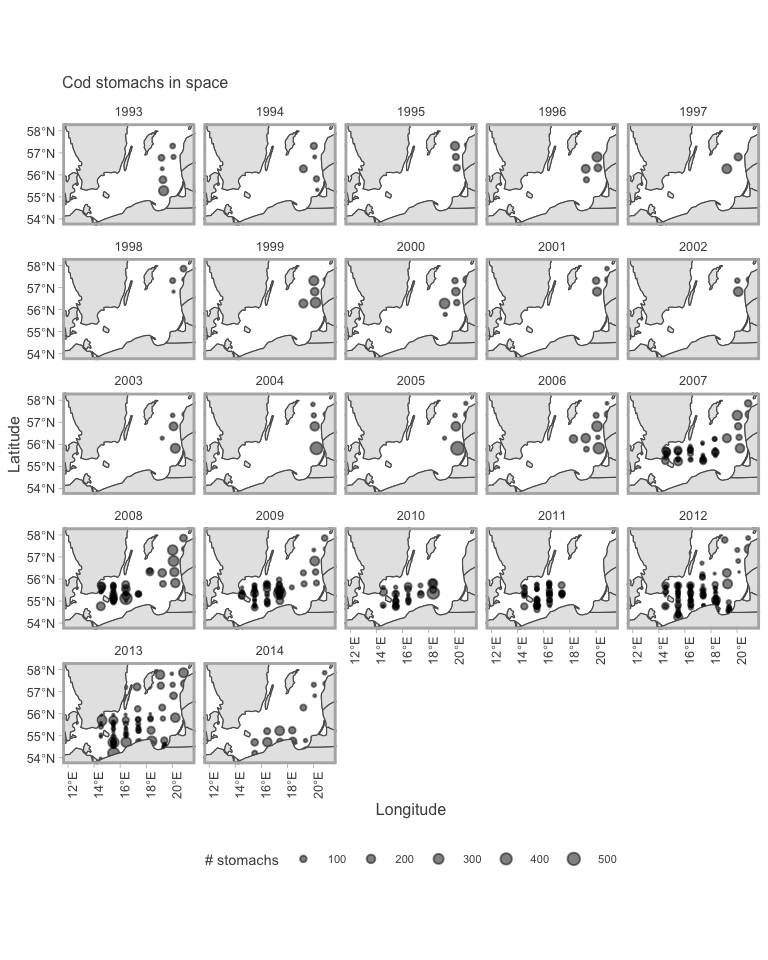

```r
plot_map_fc +
  geom_point(data = dd_plot, aes(X*1000, Y*1000, size = sample_size), alpha = 0.5) +
  facet_wrap(~ year, ncol = 5) +
  theme_sleek(base_size = 6) +
  theme(legend.position = "bottom",
        axis.text.x = element_text(angle = 90)) +
  scale_size(range = c(.01, 2), name = "# stomachs") +
  labs(title = "Cod stomachs in space") +
  geom_sf()
```

```r
# Save new data
write_csv(dd, paste0(home, "/data/clean/stefan_stomachs.csv"))
```